```python
%cd drive/MyDrive/Udacity/DeepLearning/
```

```python
from google.colab import drive
drive.mount('/content/drive')
```

# Convolutional Neural Networks

## Project: Write an Algorithm for Landmark Classification

In this notebook, some template code has already been provided for you, and you will need to implement additional functionality to successfully complete this project. You will not need to modify the included code beyond what is requested. Sections that begin with **'(IMPLEMENTATION)'** in the header indicate that the following block of code will require additional functionality which you must provide. Instructions will be provided for each section, and the specifics of the implementation are marked in the code block with a 'TODO' statement. Please be sure to read the instructions carefully!

> **Note**: Once you have completed all the code implementations, you need to finalize your work by exporting the Jupyter Notebook as an HTML document. Before exporting the notebook to HTML, all the code cells need to have been run so that reviewers can see the final implementation and output. You can then export the notebook by using the menu above and navigating to **File -> Download as -> HTML (.html)**. Include the finished document along with this notebook as your submission.

In addition to implementing code, there will be questions that you must answer which relate to the project and your implementation. Each section where you will answer a question is preceded by a **'Question X'** header. Carefully read each question and provide thorough answers in the following text boxes that begin with **'Answer:'**. Your project submission will be evaluated based on your answers to each of the questions and the implementation you provide.

> **Note:** Code and Markdown cells can be executed using the **Shift + Enter** keyboard shortcut. Markdown cells can be edited by double-clicking the cell to enter edit mode.

The rubric contains *optional* "Stand Out Suggestions" for enhancing the project beyond the minimum requirements. If you decide to pursue the "Stand Out Suggestions", you should include the code in this Jupyter notebook.

### Why We're Here

Photo sharing and photo storage services like to have location data for each photo that is uploaded. With the location data, these services can build advanced features, such as automatic suggestion of relevant tags or automatic photo organization, which help provide a compelling user experience. Although a photo's location can often be obtained by looking at the photo's metadata, many photos uploaded to these services will not have location metadata available. This can happen when, for example, the camera capturing the picture does not have GPS or if a photo's metadata is scrubbed due to privacy concerns.

If no location metadata for an image is available, one way to infer the location is to detect and classify a discernible landmark in the image. Given the large number of landmarks across the world and the immense volume of images that are uploaded to photo sharing services, using human judgement to classify these landmarks would not be feasible.

In this notebook, you will take the first steps towards addressing this problem by building models to automatically predict the location of the image based on any landmarks depicted in the image. At the end of this project, your code will accept any user-supplied image as input and suggest the top k most relevant landmarks from 50 possible landmarks from across the world. The image below displays a potential sample output of your finished project.

[figure not shown]

### The Road Ahead

We break the notebook into separate steps. Feel free to use the links below to navigate the notebook.

- Step 0: Download Datasets and Install Python Modules
- Step 1: Create a CNN to Classify Landmarks (from Scratch)
- Step 2: Create a CNN to Classify Landmarks (using Transfer Learning)
- Step 3: Write Your Landmark Prediction Algorithm

## Step 0: Download Datasets and Install Python Modules

**Note: if you are using the Udacity workspace, *YOU CAN SKIP THIS STEP*. The dataset can be found in the `/data` folder and all required Python modules have been installed in the workspace.**

Download the [landmark dataset](https://udacity-dlnfd.s3-us-west-1.amazonaws.com/datasets/landmark_images.zip). Unzip the folder and place it in this project's home directory, at the location `/landmark_images`.

Install the following Python modules:

- cv2
- matplotlib
- numpy
- PIL
- torch
- torchvision

```python
import cv2
import os
import PIL
import torch
import numpy as np
import torch.nn as nn

import functools
import operator

import torchvision
from torchvision import datasets, models, transforms
from torch.utils.data.sampler import SubsetRandomSampler
```

## Step 1: Create a CNN to Classify Landmarks (from Scratch)

In this step, you will create a CNN that classifies landmarks. You must create your CNN *from scratch* (so, you can't use transfer learning *yet*!), and you must attain a test accuracy of at least 20%.

Although 20% may seem low at first glance, it seems more reasonable after realizing how difficult of a problem this is. Many times, an image that is taken at a landmark captures a fairly mundane image of an animal or plant, like in the following picture.

[figure not shown]

Just by looking at that image alone, would you have been able to guess that it was taken at the Haleakalā National Park in Hawaii?

An accuracy of 20% is significantly better than random guessing, which would provide an accuracy of just 2%. In Step 2 of this notebook, you will have the opportunity to greatly improve accuracy by using transfer learning to create a CNN.

Remember that practice is far ahead of theory in deep learning. Experiment with many different architectures, and trust your intuition. And, of course, have fun!

### (IMPLEMENTATION) Specify Data Loaders for the Landmark Dataset

Use the code cell below to create three separate [data loaders](http://pytorch.org/docs/stable/data.html#torch.utils.data.DataLoader): one for training data, one for validation data, and one for test data. Randomly split the images located at `landmark_images/train` to create the train and validation data loaders, and use the images located at `landmark_images/test` to create the test data loader.

All three of your data loaders should be accessible via a dictionary named `loaders_scratch`. Your train data loader should be at `loaders_scratch['train']`, your validation data loader should be at `loaders_scratch['valid']`, and your test data loader should be at `loaders_scratch['test']`.

You may find [this documentation on custom datasets](https://pytorch.org/docs/stable/torchvision/datasets.html#datasetfolder) to be a useful resource. If you are interested in augmenting your training and/or validation data, check out the wide variety of [transforms](http://pytorch.org/docs/stable/torchvision/transforms.html?highlight=transform)!

```python
### TODO: Write data loaders for training, validation, and test sets
## Specify appropriate transforms, and batch_sizes
data_dir = "/content/drive/MyDrive/Udacity/DeepLearning/LandMark_Project02/landmark_images"
train_dir = os.path.join(data_dir, "train/")
test_dir = os.path.join(data_dir, "test/")

#Transformation Parameters
new_size = (128, 128)

batch_size = 20
valid_size = 0.2
num_workers = 0

data_transform = transforms.Compose([transforms.Resize(size=new_size),
                                     transforms.ToTensor()])

train_data = datasets.ImageFolder(train_dir, transform=data_transform)
test_data = datasets.ImageFolder(test_dir, transform=data_transform)
```

```python
# obtain training indices that will be used for validation
num_train = len(train_data)
indices = list(range(num_train))
np.random.shuffle(indices)
split = int(np.floor(valid_size * num_train))
train_idx, valid_idx = indices[split:], indices[:split]

# define samplers for obtaining training and validation batches
train_sampler = SubsetRandomSampler(train_idx)
valid_sampler = SubsetRandomSampler(valid_idx)

# prepare data loaders
train_loader = torch.utils.data.DataLoader(train_data, batch_size=batch_size,
    sampler=train_sampler, num_workers=num_workers)

valid_loader = torch.utils.data.DataLoader(train_data, batch_size=batch_size,
    sampler=valid_sampler, num_workers=num_workers)

test_loader = torch.utils.data.DataLoader(test_data, batch_size=batch_size,
    num_workers=num_workers)

loaders_scratch = {'train': train_loader, 'valid': valid_loader, 'test': test_loader}
```

**Question 1:** Describe your chosen procedure for preprocessing the data.

- How does your code resize the images (by cropping, stretching, etc)? What size did you pick for the input tensor, and why?
- Did you decide to augment the dataset? If so, how (through translations, flips, rotations, etc)? If not, why not?

**Answer**:

### Answer1.1:

My code resizes the images by using transforms.Resize instead of using crop. Using crop will cause the image to loss some information. The orginal image size is huge so it was reduced to 128*128 The new image size is good to keep good resolution so the network can extract good features. Reducing the image size more mean less extracted features.

### Answer1.2:

No data agumentations were added because after trying and testing RandomHorizontalFlip and RandomRotation. The model achived similar or lower results. I tested the model with both agumentations together and seperately.

### (IMPLEMENTATION) Visualize a Batch of Training Data

Use the code cell below to retrieve a batch of images from your train data loader, display at least 5 images simultaneously, and label each displayed image with its class name (e.g., "Golden Gate Bridge").

Visualizing the output of your data loader is a great way to ensure that your data loading and preprocessing are working as expected.

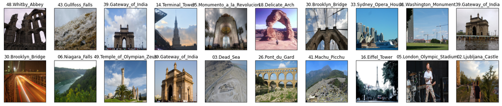

```python
import matplotlib.pyplot as plt
%matplotlib inline

## TODO: visualize a batch of the train data loader

## the class names can be accessed at the `classes` attribute
## of your dataset object (e.g., `train_dataset.classes`)
# obtain one batch of training images
dataiter = iter(train_loader)
images, labels = dataiter.next()
images = images.numpy() # convert images to numpy for display

# plot the images in the batch, along with the corresponding labels
fig = plt.figure(figsize=(25, 5))
for idx in np.arange(20):
    ax = fig.add_subplot(2, 10, idx+1, xticks=[], yticks=[])
    plt.imshow(np.transpose(images[idx], (1, 2, 0)))
    ax.set_title(train_data.classes[labels[idx]])
```

### Initialize use_cuda variable

```python
# check if CUDA is available
train_on_gpu = torch.cuda.is_available()

if not train_on_gpu:
    print('CUDA is not available.  Training on CPU ...')
else:
    print('CUDA is available!  Training on GPU ...')
```

```
CUDA is available!  Training on GPU ...
```

### (IMPLEMENTATION) Specify Loss Function and Optimizer

Use the next code cell to specify a [loss function](http://pytorch.org/docs/stable/nn.html#loss-functions) and [optimizer](http://pytorch.org/docs/stable/optim.html). Save the chosen loss function as `criterion_scratch`, and fill in the function `get_optimizer_scratch` below.

```python
## TODO: select loss function
criterion_scratch = nn.CrossEntropyLoss()

def get_optimizer_scratch(model):
    ## TODO: select and return an optimizer
    return torch.optim.SGD(model.parameters(), lr=0.01)
```

### (IMPLEMENTATION) Model Architecture

Create a CNN to classify images of landmarks. Use the template in the code cell below.

```python
import torch.nn as nn

# define the CNN architecture
class Net(nn.Module):
    ## TODO: choose an architecture, and complete the class
    def __init__(self, num_classes, channels,
                 conv_kernels, conv_strides, conv_paddings,
                 pooling_kernels, pooling_strides, pooling_paddings,
                 linears,
                 dropouts,
                 input_dim):
        super(Net, self).__init__()

        feature_layers = []
        classification_layers = []

        #Features Layers
        for index in range(1, len(channels)):
            feature_layers.append(nn.Conv2d(in_channels=channels[index-1],
                                  out_channels=channels[index],
                                  kernel_size=conv_kernels[index-1],
                                  stride=conv_strides[index-1],
                                  padding=conv_paddings[index-1]))

            feature_layers.append(nn.ReLU())

            if pooling_kernels[index-1] != 0:
                feature_layers.append(nn.MaxPool2d(pooling_kerenls[index-1],
                                           pooling_strides[index-1],
                                           pooling_paddings[index-1]))

        self.features = nn.Sequential(*feature_layers)

        #Classification Layers
        self.num_cnn_output = functools.reduce(operator.mul, list(self.features(torch.rand(1, *input_dim)).shape))

        classification_layers.append(nn.Linear(self.num_cnn_output, linears[0]))
        #classification_layers.append(nn.ReLU())

        if dropouts[0] != 0:
              classification_layers.append(nn.Dropout(p=dropouts[0]))

        for index in range(1, len(linears)):
            classification_layers.append(nn.Linear(linears[index-1], linears[index]))
            if index != len(linears)-1:
                classification_layers.append(nn.ReLU())
            if dropouts[index] != 0:
              classification_layers.append(nn.Dropout(p=dropouts[index]))

        self.classification = nn.Sequential(*classification_layers)

    def forward(self, x):
        ## Define forward behavior
        output = self.features(x)

        #flatten the output
        output = output.view(-1, self.num_cnn_output)

        output = self.classification(output)

        return output

#-#-# Do NOT modify the code below this line. #-#-#

# instantiate the CNN
num_classes = 50

channels = [3,64,128,256,512]
conv_kernels = [3,3,3,3,3]
conv_strides = [1,1,1,1,1]
conv_paddings = [1,1,1,1,1]

pooling_kerenls = [2,2,2,2,2]
pooling_strides = [2,2,2,2,2]
pooling_paddings = [0,0,0,0,0]

linears = [num_classes]

dropouts = [0]

input_dim = images[0].shape

model_scratch = Net(num_classes, channels,
                    conv_kernels, conv_strides, conv_paddings,
                    pooling_kerenls, pooling_strides, pooling_paddings,
                    linears,
                    dropouts,
                    input_dim)

# move tensors to GPU if CUDA is available
if train_on_gpu:
    model_scratch.cuda()
```

```python
model_scratch
```

```
Net(
  (features): Sequential(
    (0): Conv2d(3, 64, kernel_size=(3, 3), stride=(1, 1), padding=(1, 1))
    (1): ReLU()
    (2): MaxPool2d(kernel_size=2, stride=2, padding=0, dilation=1, ceil_mode=False)
    (3): Conv2d(64, 128, kernel_size=(3, 3), stride=(1, 1), padding=(1, 1))
    (4): ReLU()
    (5): MaxPool2d(kernel_size=2, stride=2, padding=0, dilation=1, ceil_mode=False)
    (6): Conv2d(128, 256, kernel_size=(3, 3), stride=(1, 1), padding=(1, 1))
    (7): ReLU()
    (8): MaxPool2d(kernel_size=2, stride=2, padding=0, dilation=1, ceil_mode=False)
    (9): Conv2d(256, 512, kernel_size=(3, 3), stride=(1, 1), padding=(1, 1))
    (10): ReLU()
    (11): MaxPool2d(kernel_size=2, stride=2, padding=0, dilation=1, ceil_mode=False)
  )
  (classification): Sequential(
    (0): Linear(in_features=32768, out_features=50, bias=True)
  )
)
```

**Question 2:** Outline the steps you took to get to your final CNN architecture and your reasoning at each step.

**Answer:**  
I started testing with AlexNet architecture. it accomplished the job for long epochs. However, I noticed a pattern in some known architectures. The number of channels started with 3, 64, 128, 256, 512 and so on. As a result, I decided to train a model with a simpler architecture and find the simplest architecture that could achive the required result.

The architecture with the following parameters achived the required result.

```
num_classes = 50

channels = [3,64,128,256,512]
conv_kernels = [3,3,3,3,3]
conv_strides = [1,1,1,1,1]
conv_paddings = [1,1,1,1,1]

pooling_kerenls = [2,2,2,2,2]
pooling_strides = [2,2,2,2,2]
pooling_paddings = [0,0,0,0,0]

linears = [num_classes]

dropouts = [0]
```

### (IMPLEMENTATION) Implement the Training Algorithm

Implement your training algorithm in the code cell below. [Save the final model parameters](http://pytorch.org/docs/master/notes/serialization.html) at the filepath stored in the variable `save_path`.

```python
def train(n_epochs, loaders, model, optimizer, criterion, use_cuda, save_path):
    """returns trained model"""
    # initialize tracker for minimum validation loss
    valid_loss_min = np.Inf

    for epoch in range(1, n_epochs+1):
        # initialize variables to monitor training and validation loss
        train_correct = 0.0
        train_loss = 0.0

        valid_correct = 0.0
        valid_loss = 0.0

        ###################
        # train the model #
        ###################
        # set the module to training mode
        model.train()
        for batch_idx, (data, target) in enumerate(loaders['train']):
            # move to GPU
            if use_cuda:
                data, target = data.cuda(), target.cuda()

            ## TODO: find the loss and update the model parameters accordingly
            ## record the average training loss, using something like
            ## train_loss = train_loss + ((1 / (batch_idx + 1)) * (loss.data.item() - train_loss))

            # clear the gradients of all optimized variables
            optimizer.zero_grad()
            # forward pass: compute predicted outputs by passing inputs to the model
            output = model(data)
            # calculate the loss
            loss = criterion(output, target)
            # backward pass: compute gradient of the loss with respect to model parameters
            loss.backward()
            # perform a single optimization step (parameter update)
            optimizer.step()
            # sum all the correct predictions to find the training accuracy
            _, predicted_labels = output.max(1)
            train_correct += (predicted_labels == target).float().sum().cpu().numpy()
            # update running training loss
            train_loss += ((1 / (batch_idx + 1)) * (loss.data.item() - train_loss))
            # print updates every 5 batches
            if (batch_idx + 1) % 5 == 0:
                print(f"Epoch: {epoch} \tBatch Index: {batch_idx+1} \tTraining Loss: {train_loss}")

        ######################
        # validate the model #
        ######################
        # set the model to evaluation mode
        model.eval()
        for batch_idx, (data, target) in enumerate(loaders['valid']):
            # move to GPU
            if use_cuda:
                data, target = data.cuda(), target.cuda()

            ## TODO: update average validation loss

            # forward pass: compute predicted outputs by passing inputs to the model
            output = model(data)
            # calculate the loss
            loss = criterion(output, target)
            # sum all the correct predictions to find the validation accuracy
            _, predicted_labels = output.max(1)
            valid_correct += (predicted_labels == target).float().sum().cpu().numpy()
            # update running validation loss
            valid_loss += ((1 / (batch_idx + 1)) * (loss.data.item() - valid_loss))

        # print training/validation statistics
        print('Epoch: {} \tTraining Loss: {:.6f} \tTraining Accuracy: {:.6f}% \tValidation Loss: {:.6f} \tValidation Accuracy {:.6f}%'.format(
            epoch,
            train_loss,
            (train_correct/len(loaders["train"])),
            valid_loss,
            (valid_correct/len(loaders["valid"]))
            ))

        ## TODO: if the validation loss has decreased, save the model at the filepath stored in save_path

        # save model if validation loss has decreased
        if valid_loss <= valid_loss_min:
            print('Validation loss decreased ({:.6f} --> {:.6f}).  Saving model ...'.format(
            valid_loss_min,
            valid_loss))
            torch.save(model.state_dict(), save_path)
            valid_loss_min = valid_loss

    return model
```

### (IMPLEMENTATION) Experiment with the Weight Initialization

Use the code cell below to define a custom weight initialization, and then train with your weight initialization for a few epochs. Make sure that neither the training loss nor validation loss is `nan`.

Later on, you will be able to see how this compares to training with PyTorch's default weight initialization.

```python
def custom_weight_init(m):
    ## TODO: implement a weight initialization strategy
    if type(m) == nn.Linear:
        n = m.in_features
        y = 1.0/np.sqrt(n)
        m.weight.data.uniform_(-y*2,y*2)
        m.bias.data.fill_(0)

#-#-# Do NOT modify the code below this line. #-#-#

model_scratch.apply(custom_weight_init)
model_scratch = train(20, loaders_scratch, model_scratch, get_optimizer_scratch(model_scratch),
                      criterion_scratch, train_on_gpu, 'ignore.pt')
```

```
Epoch: 1 	Batch Index: 5 	Training Loss: 3.9162019729614257
Epoch: 1 	Batch Index: 10 	Training Loss: 3.9113087177276604
Epoch: 1 	Batch Index: 15 	Training Loss: 3.913871002197265
Epoch: 1 	Batch Index: 20 	Training Loss: 3.913367593288421
Epoch: 1 	Batch Index: 25 	Training Loss: 3.9143392467498774
Epoch: 1 	Batch Index: 30 	Training Loss: 3.913285414377848
Epoch: 1 	Batch Index: 35 	Training Loss: 3.9140328816005163
Epoch: 1 	Batch Index: 40 	Training Loss: 3.9131018400192263
Epoch: 1 	Batch Index: 45 	Training Loss: 3.914198928409153
Epoch: 1 	Batch Index: 50 	Training Loss: 3.9141130399703985
Epoch: 1 	Batch Index: 55 	Training Loss: 3.9142599626020953
Epoch: 1 	Batch Index: 60 	Training Loss: 3.9139156977335614
Epoch: 1 	Batch Index: 65 	Training Loss: 3.913466453552246
Epoch: 1 	Batch Index: 70 	Training Loss: 3.9139802489961895
Epoch: 1 	Batch Index: 75 	Training Loss: 3.9138279565175376
Epoch: 1 	Batch Index: 80 	Training Loss: 3.913475069403648
Epoch: 1 	Batch Index: 85 	Training Loss: 3.9131935484269085
Epoch: 1 	Batch Index: 90 	Training Loss: 3.913128058115641
Epoch: 1 	Batch Index: 95 	Training Loss: 3.9125927122015702
Epoch: 1 	Batch Index: 100 	Training Loss: 3.912630732059479
Epoch: 1 	Batch Index: 105 	Training Loss: 3.912692419687907
Epoch: 1 	Batch Index: 110 	Training Loss: 3.912511344389482
Epoch: 1 	Batch Index: 115 	Training Loss: 3.9127699105635934
Epoch: 1 	Batch Index: 120 	Training Loss: 3.912852462132772
Epoch: 1 	Batch Index: 125 	Training Loss: 3.912595788955689
Epoch: 1 	Batch Index: 130 	Training Loss: 3.9125539119427026
Epoch: 1 	Batch Index: 135 	Training Loss: 3.9127107337669096
Epoch: 1 	Batch Index: 140 	Training Loss: 3.9124587808336537
Epoch: 1 	Batch Index: 145 	Training Loss: 3.9120142624295995
Epoch: 1 	Batch Index: 150 	Training Loss: 3.9123293828964236
Epoch: 1 	Batch Index: 155 	Training Loss: 3.912059325556601
Epoch: 1 	Batch Index: 160 	Training Loss: 3.9121255487203594
Epoch: 1 	Batch Index: 165 	Training Loss: 3.911798685247248
Epoch: 1 	Batch Index: 170 	Training Loss: 3.911585186509525
Epoch: 1 	Batch Index: 175 	Training Loss: 3.9117020620618552
Epoch: 1 	Batch Index: 180 	Training Loss: 3.9116151306364273
Epoch: 1 	Batch Index: 185 	Training Loss: 3.911451146409318
Epoch: 1 	Batch Index: 190 	Training Loss: 3.9113410560708295
Epoch: 1 	Batch Index: 195 	Training Loss: 3.9111967025659027
Epoch: 1 	Batch Index: 200 	Training Loss: 3.9112132573127747
```

[output cut: 774 more lines]

```
Epoch: 20 	Batch Index: 135 	Training Loss: 0.2958850368305489
Epoch: 20 	Batch Index: 140 	Training Loss: 0.302928125006812
Epoch: 20 	Batch Index: 145 	Training Loss: 0.30629341910625324
Epoch: 20 	Batch Index: 150 	Training Loss: 0.31008921245733895
Epoch: 20 	Batch Index: 155 	Training Loss: 0.31008761116573885
Epoch: 20 	Batch Index: 160 	Training Loss: 0.3071440618019551
Epoch: 20 	Batch Index: 165 	Training Loss: 0.30718674822287123
Epoch: 20 	Batch Index: 170 	Training Loss: 0.31217091802288505
Epoch: 20 	Batch Index: 175 	Training Loss: 0.3117485830613545
Epoch: 20 	Batch Index: 180 	Training Loss: 0.30996209950082837
Epoch: 20 	Batch Index: 185 	Training Loss: 0.3095818924340043
Epoch: 20 	Batch Index: 190 	Training Loss: 0.3096139802352379
Epoch: 20 	Batch Index: 195 	Training Loss: 0.3113266570827901
Epoch: 20 	Batch Index: 200 	Training Loss: 0.3114962962642313
Epoch: 20 	Training Loss: 0.311496 	Training Accuracy: 18.305000% 	Validation Loss: 5.764152 	Validation Accuracy 4.740000%
```

### (IMPLEMENTATION) Train and Validate the Model

Run the next code cell to train your model.

```python
## TODO: you may change the number of epochs if you'd like,
## but changing it is not required
num_epochs = 20

#-#-# Do NOT modify the code below this line. #-#-#

# function to re-initialize a model with pytorch's default weight initialization
def default_weight_init(m):
    reset_parameters = getattr(m, 'reset_parameters', None)
    if callable(reset_parameters):
        m.reset_parameters()

# reset the model parameters
model_scratch.apply(default_weight_init)

# train the model
model_scratch = train(num_epochs, loaders_scratch, model_scratch, get_optimizer_scratch(model_scratch),
                      criterion_scratch, train_on_gpu, 'model_scratch.pt')
```

```
Epoch: 1 	Batch Index: 5 	Training Loss: 3.9114097595214843
Epoch: 1 	Batch Index: 10 	Training Loss: 3.910555434226989
Epoch: 1 	Batch Index: 15 	Training Loss: 3.913119475046793
Epoch: 1 	Batch Index: 20 	Training Loss: 3.91243017911911
Epoch: 1 	Batch Index: 25 	Training Loss: 3.91304235458374
Epoch: 1 	Batch Index: 30 	Training Loss: 3.9135523478190106
Epoch: 1 	Batch Index: 35 	Training Loss: 3.9135454927171978
Epoch: 1 	Batch Index: 40 	Training Loss: 3.913271450996399
Epoch: 1 	Batch Index: 45 	Training Loss: 3.913203001022339
Epoch: 1 	Batch Index: 50 	Training Loss: 3.912918090820313
Epoch: 1 	Batch Index: 55 	Training Loss: 3.9129101449793042
Epoch: 1 	Batch Index: 60 	Training Loss: 3.9129268606503804
Epoch: 1 	Batch Index: 65 	Training Loss: 3.913300426189716
Epoch: 1 	Batch Index: 70 	Training Loss: 3.9128254924501693
Epoch: 1 	Batch Index: 75 	Training Loss: 3.912770522435506
Epoch: 1 	Batch Index: 80 	Training Loss: 3.913061279058456
Epoch: 1 	Batch Index: 85 	Training Loss: 3.9125887253705183
Epoch: 1 	Batch Index: 90 	Training Loss: 3.912352720896402
Epoch: 1 	Batch Index: 95 	Training Loss: 3.9123092350206865
Epoch: 1 	Batch Index: 100 	Training Loss: 3.9126747655868512
Epoch: 1 	Batch Index: 105 	Training Loss: 3.912795779818579
Epoch: 1 	Batch Index: 110 	Training Loss: 3.9132292942567295
Epoch: 1 	Batch Index: 115 	Training Loss: 3.913232842735621
Epoch: 1 	Batch Index: 120 	Training Loss: 3.913049219051995
Epoch: 1 	Batch Index: 125 	Training Loss: 3.9131854610443098
Epoch: 1 	Batch Index: 130 	Training Loss: 3.9133602160673857
Epoch: 1 	Batch Index: 135 	Training Loss: 3.913113175498113
Epoch: 1 	Batch Index: 140 	Training Loss: 3.913306379318235
Epoch: 1 	Batch Index: 145 	Training Loss: 3.913118023707947
Epoch: 1 	Batch Index: 150 	Training Loss: 3.913063866297402
Epoch: 1 	Batch Index: 155 	Training Loss: 3.9129233806363977
Epoch: 1 	Batch Index: 160 	Training Loss: 3.9128643155097937
Epoch: 1 	Batch Index: 165 	Training Loss: 3.912938869360719
Epoch: 1 	Batch Index: 170 	Training Loss: 3.9131322874742374
Epoch: 1 	Batch Index: 175 	Training Loss: 3.9130957004002145
Epoch: 1 	Batch Index: 180 	Training Loss: 3.9130784140692803
Epoch: 1 	Batch Index: 185 	Training Loss: 3.913104688799058
Epoch: 1 	Batch Index: 190 	Training Loss: 3.913072956235784
Epoch: 1 	Batch Index: 195 	Training Loss: 3.913121996170434
Epoch: 1 	Batch Index: 200 	Training Loss: 3.9129352271556845
```

[output cut: 774 more lines]

```
Epoch: 20 	Batch Index: 135 	Training Loss: 0.3965471169462911
Epoch: 20 	Batch Index: 140 	Training Loss: 0.3971569722252233
Epoch: 20 	Batch Index: 145 	Training Loss: 0.3942136055436628
Epoch: 20 	Batch Index: 150 	Training Loss: 0.4005975063641866
Epoch: 20 	Batch Index: 155 	Training Loss: 0.4031769749618346
Epoch: 20 	Batch Index: 160 	Training Loss: 0.4070029308088124
Epoch: 20 	Batch Index: 165 	Training Loss: 0.4103216995795568
Epoch: 20 	Batch Index: 170 	Training Loss: 0.40981834311695653
Epoch: 20 	Batch Index: 175 	Training Loss: 0.4127593029396874
Epoch: 20 	Batch Index: 180 	Training Loss: 0.4151975933876302
Epoch: 20 	Batch Index: 185 	Training Loss: 0.4154408155260858
Epoch: 20 	Batch Index: 190 	Training Loss: 0.41647197541437636
Epoch: 20 	Batch Index: 195 	Training Loss: 0.41771870438869174
Epoch: 20 	Batch Index: 200 	Training Loss: 0.41726464793086043
Epoch: 20 	Training Loss: 0.417265 	Training Accuracy: 17.705000% 	Validation Loss: 5.328706 	Validation Accuracy 5.200000%
```

### (IMPLEMENTATION) Test the Model

Run the code cell below to try out your model on the test dataset of landmark images. Run the code cell below to calculate and print the test loss and accuracy. Ensure that your test accuracy is greater than 20%.

```python
def test(loaders, model, criterion, use_cuda):

    # monitor test loss and accuracy
    test_loss = 0.
    correct = 0.
    total = 0.

    # set the module to evaluation mode
    model.eval()

    for batch_idx, (data, target) in enumerate(loaders['test']):
        # move to GPU
        if use_cuda:
            data, target = data.cuda(), target.cuda()
        # forward pass: compute predicted outputs by passing inputs to the model
        output = model(data)
        # calculate the loss
        loss = criterion(output, target)
        # update average test loss
        test_loss = test_loss + ((1 / (batch_idx + 1)) * (loss.data.item() - test_loss))
        # convert output probabilities to predicted class
        pred = output.data.max(1, keepdim=True)[1]
        # compare predictions to true label
        correct += np.sum(np.squeeze(pred.eq(target.data.view_as(pred))).cpu().numpy())
        total += data.size(0)

    print('Test Loss: {:.6f}\n'.format(test_loss))

    print('\nTest Accuracy: %2d%% (%2d/%2d)' % (
        100. * correct / total, correct, total))

# load the model that got the best validation accuracy
model_scratch.load_state_dict(torch.load('model_scratch.pt'))
test(loaders_scratch, model_scratch, criterion_scratch, train_on_gpu)
```

```
Test Loss: 3.096560


Test Accuracy: 24% (312/1250)
```

## Step 2: Create a CNN to Classify Landmarks (using Transfer Learning)

You will now use transfer learning to create a CNN that can identify landmarks from images. Your CNN must attain at least 60% accuracy on the test set.

### (IMPLEMENTATION) Specify Data Loaders for the Landmark Dataset

Use the code cell below to create three separate [data loaders](http://pytorch.org/docs/stable/data.html#torch.utils.data.DataLoader): one for training data, one for validation data, and one for test data. Randomly split the images located at `landmark_images/train` to create the train and validation data loaders, and use the images located at `landmark_images/test` to create the test data loader.

All three of your data loaders should be accessible via a dictionary named `loaders_transfer`. Your train data loader should be at `loaders_transfer['train']`, your validation data loader should be at `loaders_transfer['valid']`, and your test data loader should be at `loaders_transfer['test']`.

If you like, **you are welcome to use the same data loaders from the previous step**, when you created a CNN from scratch.

```python
### TODO: Write data loaders for training, validation, and test sets
## Specify appropriate transforms, and batch_sizes
loaders_transfer = {'train': train_loader, 'valid': valid_loader, 'test': test_loader}
```

### (IMPLEMENTATION) Specify Loss Function and Optimizer

Use the next code cell to specify a [loss function](http://pytorch.org/docs/stable/nn.html#loss-functions) and [optimizer](http://pytorch.org/docs/stable/optim.html). Save the chosen loss function as `criterion_transfer`, and fill in the function `get_optimizer_transfer` below.

```python
## TODO: select loss function
criterion_transfer = nn.CrossEntropyLoss()


def get_optimizer_transfer(model):
    ## TODO: select and return optimizer
    return torch.optim.SGD(model.parameters(), lr=0.01)
```

### (IMPLEMENTATION) Model Architecture

Use transfer learning to create a CNN to classify images of landmarks. Use the code cell below, and save your initialized model as the variable `model_transfer`.

```python
## TODO: Specify model architecture
from torchvision import models
model_transfer = models.vgg16(pretrained=True)

for param in model_transfer.parameters():
    param.requires_grad = False

model_transfer.classifier[6] = nn.Linear(4096, 50)

#-#-# Do NOT modify the code below this line. #-#-#

if train_on_gpu:
    model_transfer = model_transfer.cuda()
```

```
Downloading: "https://download.pytorch.org/models/vgg16-397923af.pth" to /root/.cache/torch/hub/checkpoints/vgg16-397923af.pth
```

```python
model_transfer
```

```
VGG(
  (features): Sequential(
    (0): Conv2d(3, 64, kernel_size=(3, 3), stride=(1, 1), padding=(1, 1))
    (1): ReLU(inplace=True)
    (2): Conv2d(64, 64, kernel_size=(3, 3), stride=(1, 1), padding=(1, 1))
    (3): ReLU(inplace=True)
    (4): MaxPool2d(kernel_size=2, stride=2, padding=0, dilation=1, ceil_mode=False)
    (5): Conv2d(64, 128, kernel_size=(3, 3), stride=(1, 1), padding=(1, 1))
    (6): ReLU(inplace=True)
    (7): Conv2d(128, 128, kernel_size=(3, 3), stride=(1, 1), padding=(1, 1))
    (8): ReLU(inplace=True)
    (9): MaxPool2d(kernel_size=2, stride=2, padding=0, dilation=1, ceil_mode=False)
    (10): Conv2d(128, 256, kernel_size=(3, 3), stride=(1, 1), padding=(1, 1))
    (11): ReLU(inplace=True)
    (12): Conv2d(256, 256, kernel_size=(3, 3), stride=(1, 1), padding=(1, 1))
    (13): ReLU(inplace=True)
    (14): Conv2d(256, 256, kernel_size=(3, 3), stride=(1, 1), padding=(1, 1))
    (15): ReLU(inplace=True)
    (16): MaxPool2d(kernel_size=2, stride=2, padding=0, dilation=1, ceil_mode=False)
    (17): Conv2d(256, 512, kernel_size=(3, 3), stride=(1, 1), padding=(1, 1))
    (18): ReLU(inplace=True)
    (19): Conv2d(512, 512, kernel_size=(3, 3), stride=(1, 1), padding=(1, 1))
    (20): ReLU(inplace=True)
    (21): Conv2d(512, 512, kernel_size=(3, 3), stride=(1, 1), padding=(1, 1))
    (22): ReLU(inplace=True)
    (23): MaxPool2d(kernel_size=2, stride=2, padding=0, dilation=1, ceil_mode=False)
    (24): Conv2d(512, 512, kernel_size=(3, 3), stride=(1, 1), padding=(1, 1))
    (25): ReLU(inplace=True)
    (26): Conv2d(512, 512, kernel_size=(3, 3), stride=(1, 1), padding=(1, 1))
    (27): ReLU(inplace=True)
    (28): Conv2d(512, 512, kernel_size=(3, 3), stride=(1, 1), padding=(1, 1))
    (29): ReLU(inplace=True)
    (30): MaxPool2d(kernel_size=2, stride=2, padding=0, dilation=1, ceil_mode=False)
  )
  (avgpool): AdaptiveAvgPool2d(output_size=(7, 7))
  (classifier): Sequential(
    (0): Linear(in_features=25088, out_features=4096, bias=True)
    (1): ReLU(inplace=True)
    (2): Dropout(p=0.5, inplace=False)
    (3): Linear(in_features=4096, out_features=4096, bias=True)
    (4): ReLU(inplace=True)
    (5): Dropout(p=0.5, inplace=False)
    (6): Linear(in_features=4096, out_features=50, bias=True)
  )
)
```

**Question 3:** Outline the steps you took to get to your final CNN architecture and your reasoning at each step. Describe why you think the architecture is suitable for the current problem.

**Answer:**  
The dataset consist of 3997 images with 50 different classes. The dataset is considered small and the images are similar. As a result, End of Conv transfer learning technique will be used to train the model.

I will start with AlexNet and determine if the problem requires more complex architecture or not.

[output not shown]

### (IMPLEMENTATION) Train and Validate the Model

Train and validate your model in the code cell below. [Save the final model parameters](http://pytorch.org/docs/master/notes/serialization.html) at filepath `'model_transfer.pt'`.

```python
# TODO: train the model and save the best model parameters at filepath 'model_transfer.pt'
num_epochs = 20

model_transfer = train(num_epochs, loaders_transfer, model_transfer, get_optimizer_transfer(model_transfer),
                      criterion_transfer, train_on_gpu, 'model_transfer.pt')

#-#-# Do NOT modify the code below this line. #-#-#

# load the model that got the best validation accuracy
model_transfer.load_state_dict(torch.load('model_transfer.pt'))
```

```
Epoch: 1 	Batch Index: 5 	Training Loss: 3.991297388076782
Epoch: 1 	Batch Index: 10 	Training Loss: 3.873888373374939
Epoch: 1 	Batch Index: 15 	Training Loss: 3.775502586364746
Epoch: 1 	Batch Index: 20 	Training Loss: 3.7070395827293394
Epoch: 1 	Batch Index: 25 	Training Loss: 3.661927213668823
Epoch: 1 	Batch Index: 30 	Training Loss: 3.574848866462707
Epoch: 1 	Batch Index: 35 	Training Loss: 3.557597139903477
Epoch: 1 	Batch Index: 40 	Training Loss: 3.4656693637371063
Epoch: 1 	Batch Index: 45 	Training Loss: 3.358798556857639
Epoch: 1 	Batch Index: 50 	Training Loss: 3.313347606658935
Epoch: 1 	Batch Index: 55 	Training Loss: 3.2702731305902653
Epoch: 1 	Batch Index: 60 	Training Loss: 3.2428539117177326
Epoch: 1 	Batch Index: 65 	Training Loss: 3.195079407325158
Epoch: 1 	Batch Index: 70 	Training Loss: 3.1637120519365585
Epoch: 1 	Batch Index: 75 	Training Loss: 3.1283384990692142
Epoch: 1 	Batch Index: 80 	Training Loss: 3.1166077792644504
Epoch: 1 	Batch Index: 85 	Training Loss: 3.0744408803827628
Epoch: 1 	Batch Index: 90 	Training Loss: 3.048875416649713
Epoch: 1 	Batch Index: 95 	Training Loss: 3.024172491776316
Epoch: 1 	Batch Index: 100 	Training Loss: 2.9905803275108336
Epoch: 1 	Batch Index: 105 	Training Loss: 2.9720369452521913
Epoch: 1 	Batch Index: 110 	Training Loss: 2.9374711708589034
Epoch: 1 	Batch Index: 115 	Training Loss: 2.9121748654738715
Epoch: 1 	Batch Index: 120 	Training Loss: 2.891174550851186
Epoch: 1 	Batch Index: 125 	Training Loss: 2.8675612907409667
Epoch: 1 	Batch Index: 130 	Training Loss: 2.8529660921830393
Epoch: 1 	Batch Index: 135 	Training Loss: 2.8265148374769415
Epoch: 1 	Batch Index: 140 	Training Loss: 2.802748837641307
Epoch: 1 	Batch Index: 145 	Training Loss: 2.790069887555878
Epoch: 1 	Batch Index: 150 	Training Loss: 2.766277012030283
Epoch: 1 	Batch Index: 155 	Training Loss: 2.7510029800476556
Epoch: 1 	Batch Index: 160 	Training Loss: 2.731864366680383
Epoch: 1 	Batch Index: 165 	Training Loss: 2.7246651858994446
Epoch: 1 	Batch Index: 170 	Training Loss: 2.7106873729649705
Epoch: 1 	Batch Index: 175 	Training Loss: 2.690912246022905
Epoch: 1 	Batch Index: 180 	Training Loss: 2.6776394327481583
Epoch: 1 	Batch Index: 185 	Training Loss: 2.6644882891629194
Epoch: 1 	Batch Index: 190 	Training Loss: 2.6465605917729826
Epoch: 1 	Batch Index: 195 	Training Loss: 2.6315565335444915
Epoch: 1 	Batch Index: 200 	Training Loss: 2.6224847608804702
```

[output cut: 776 more lines]

```
Epoch: 20 	Batch Index: 135 	Training Loss: 0.7688919317943077
Epoch: 20 	Batch Index: 140 	Training Loss: 0.7737640605441161
Epoch: 20 	Batch Index: 145 	Training Loss: 0.7754492647688963
Epoch: 20 	Batch Index: 150 	Training Loss: 0.7735923042893409
Epoch: 20 	Batch Index: 155 	Training Loss: 0.7688307693889063
Epoch: 20 	Batch Index: 160 	Training Loss: 0.7661955867893993
Epoch: 20 	Batch Index: 165 	Training Loss: 0.7675111265796603
Epoch: 20 	Batch Index: 170 	Training Loss: 0.7715982536182682
Epoch: 20 	Batch Index: 175 	Training Loss: 0.7699976225410187
Epoch: 20 	Batch Index: 180 	Training Loss: 0.7683221203585464
Epoch: 20 	Batch Index: 185 	Training Loss: 0.7692964137405962
Epoch: 20 	Batch Index: 190 	Training Loss: 0.7690236037499025
Epoch: 20 	Batch Index: 195 	Training Loss: 0.7720194540726831
Epoch: 20 	Batch Index: 200 	Training Loss: 0.7769924803823232
Epoch: 20 	Training Loss: 0.776992 	Training Accuracy: 15.460000% 	Validation Loss: 1.564738 	Validation Accuracy 11.760000%
```

```
<All keys matched successfully>
```

### (IMPLEMENTATION) Test the Model

Try out your model on the test dataset of landmark images. Use the code cell below to calculate and print the test loss and accuracy. Ensure that your test accuracy is greater than 60%.

```python
test(loaders_transfer, model_transfer, criterion_transfer, train_on_gpu)
```

```
Test Loss: 1.316159


Test Accuracy: 65% (818/1250)
```

## Step 3: Write Your Landmark Prediction Algorithm

Great job creating your CNN models! Now that you have put in all the hard work of creating accurate classifiers, let's define some functions to make it easy for others to use your classifiers.

### (IMPLEMENTATION) Write Your Algorithm, Part 1

Implement the function `predict_landmarks`, which accepts a file path to an image and an integer k, and then predicts the **top k most likely landmarks**. You are **required** to use your transfer learned CNN from Step 2 to predict the landmarks.

An example of the expected behavior of `predict_landmarks`:

```
>>> predicted_landmarks = predict_landmarks('example_image.jpg', 3)
>>> print(predicted_landmarks)
['Golden Gate Bridge', 'Brooklyn Bridge', 'Sydney Harbour Bridge']
```

```python
import cv2
from PIL import Image

## the class names can be accessed at the `classes` attribute
## of your dataset object (e.g., `train_dataset.classes`)

new_size = (128,128)

data_transform = transforms.Compose([transforms.Resize(size=new_size),
                                     transforms.ToTensor()])

def predict_landmarks(img_path, k):
    ## TODO: return the names of the top k landmarks predicted by the transfer learned CNN
    image = Image.open(img_path)
    image = data_transform(image).float()
    image = image.unsqueeze(0).cuda()

    model_transfer.eval()
    output = model_transfer(image)
    prob = nn.functional.softmax(output, dim=1)
    top_p, top_class = prob.topk(k, dim=1)

    top_class = top_class.cpu().numpy()[0]
    top_k = []
    for i in top_class:
      top_k.append(train_data.classes[i])

    return top_k

# test on a sample image
predict_landmarks('/content/drive/MyDrive/Udacity/DeepLearning/LandMark_Project02/landmark_images/test/09.Golden_Gate_Bridge/190f3bae17c32c37.jpg', 5)
```

```
['09.Golden_Gate_Bridge',
 '38.Forth_Bridge',
 '30.Brooklyn_Bridge',
 '03.Dead_Sea',
 '45.Temple_of_Heaven']
```

### (IMPLEMENTATION) Write Your Algorithm, Part 2

In the code cell below, implement the function `suggest_locations`, which accepts a file path to an image as input, and then displays the image and the **top 3 most likely landmarks** as predicted by `predict_landmarks`.

Some sample output for `suggest_locations` is provided below, but feel free to design your own user experience!

[figure not shown]

```
['09.Golden_Gate_Bridge', '38.Forth_Bridge', '30.Brooklyn_Bridge']
```

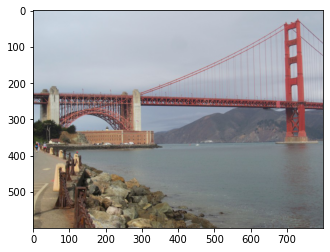

```python
def suggest_locations(img_path):
    # get landmark predictions
    predicted_landmarks = predict_landmarks(img_path, 3)

    ## TODO: display image and display landmark predictions
    image = Image.open(img_path)
    plt.imshow(image)
    return predicted_landmarks



# test on a sample image
suggest_locations('/content/drive/MyDrive/Udacity/DeepLearning/LandMark_Project02/landmark_images/test/09.Golden_Gate_Bridge/190f3bae17c32c37.jpg')
```

### (IMPLEMENTATION) Test Your Algorithm

Test your algorithm by running the `suggest_locations` function on at least four images on your computer. Feel free to use any images you like.

**Question 4:** Is the output better than you expected :) ? Or worse :( ? Provide at least three possible points of improvement for your algorithm.

**Answer:** (Three possible points for improvement) Amazingly the transferred model exceeded my expectations. The algorithm can be improved by:

1. adding some regularization like dropout to the scratch_model
2. Normalizing the data before training using pytorch transforms
3. Using batch normalizaiton layers
4. Increase the number of epochs and add some early stopping

```
['09.Golden_Gate_Bridge', '30.Brooklyn_Bridge', '38.Forth_Bridge']
```

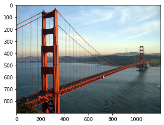

```python
## TODO: Execute the `suggest_locations` function on
## at least 4 images on your computer.
## Feel free to use as many code cells as needed.

suggest_locations('/content/drive/MyDrive/Udacity/DeepLearning/LandMark_Project02/GoldenGateBridge.jpg')
```

```
['33.Sydney_Opera_House', '06.Niagara_Falls', '00.Haleakala_National_Park']
```

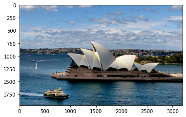

```python
suggest_locations('/content/drive/MyDrive/Udacity/DeepLearning/LandMark_Project02/SydneyOperaHouse.jpg')
```

```
['40.Stockholm_City_Hall', '30.Brooklyn_Bridge', '21.Taj_Mahal']
```

[figure not shown]

```python
suggest_locations('/content/drive/MyDrive/Udacity/DeepLearning/LandMark_Project02/TajMahal.jpg')
```

```
['46.Great_Wall_of_China', '43.Gullfoss_Falls', '41.Machu_Picchu']
```

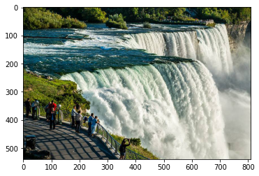

```python
suggest_locations('/content/drive/MyDrive/Udacity/DeepLearning/LandMark_Project02/NiagaraFalls.jpg')
```